# Abschlussprojekt zu Eheschliessungen vom 16. bis 18. Jahrhundert

In Kirchgemeinden des Kantons Zürich

Author

Jenny Sojka

Published

December 10, 2025

```r
library(tidyverse)
library(readr)
library(here)
library(statR)
library(ggthemes)
library(gt)
```

```r
read_csv(here::here("daten/raw/EDB_16_18_Jh_Stand_2024_05_14.csv"))
```

```
# A tibble: 296,207 × 20
   Signatur   Nachname_Mann Vorname_Mann Herkunft_Mann HLS_Artikel_Mann GND_Mann
   <chr>      <chr>         <chr>        <chr>         <lgl>            <lgl>
 1 TAI 1.725… Iringer       Heinrich     Richterswil   NA               NA
 2 TAI 1.725… Kräutli       Oswald       <NA>          NA               NA
 3 TAI 1.725… Nussbaumer    Jeremias     <NA>          NA               NA
 4 TAI 1.725… Geilinger     Wolfgang     <NA>          NA               NA
 5 TAI 1.725… Wehrli        Marx         <NA>          NA               NA
 6 TAI 1.725… Schwaninger   Hans Ulrich  <NA>          NA               NA
 7 TAI 1.725… Bucher        Schwideri    <NA>          NA               NA
 8 TAI 1.725… Dingli        Hans         <NA>          NA               NA
 9 TAI 1.725… Wahl          Martin       Ulm (Deutsch… NA               NA
10 TAI 1.725… Kappeler      Jakob        <NA>          NA               NA
# ℹ 296,197 more rows
# ℹ 14 more variables: Nachname_Frau <chr>, Vorname_Frau <chr>,
#   Herkunft_Frau <chr>, HLS_Artikel_Frau <lgl>, GND_Frau <lgl>,
#   Zusatzinfo_Mann <chr>, Zusatzinfo_Frau <chr>, Datum <chr>,
#   Datum_Von <date>, Datum_Bis <date>, Kirchgemeinde <chr>, Band <chr>,
#   Webseite <chr>, ID <dbl>
```

# Einleitung

Dieses Projekt entstand im Kontext der Weiterbildung “Statistics in R” vom Kanton Zürich. Es werden die Daten zu den “Eheschliessungen im Kanton Zürich vom 16. bis 18. Jahrhundert” (bereits OGD) mit R statistisch ausgewertet.

# Daten

Die Datensammlung enthält in standardisierter Kurzform alle Eheeinträge, die in den überlieferten Kirchenbüchern der Kirchgemeinden des Kantons Zürich seit der Reformation verzeichnet sind. Die Datensammlung wurde ursprünglich von einem privaten Genealogen erstellt. Nach dem Erwerb durch das Staatsarchiv wurden die Einträge kontrolliert, ergänzt und 2015 und 2019 in zwei Schritten online publiziert (siehe auch: https://archives-quickaccess.ch/search/stazh/edb).

### Daten laden

```r
Ehedaten_16_bis_18Jh <- read_csv(here::here("daten/raw/EDB_16_18_Jh_Stand_2024_05_14.csv"))
```

### Daten aufbereiten

```r
Ehedaten_16_bis_18Jh <- Ehedaten_16_bis_18Jh |>
  select(Nachname_Mann, Vorname_Mann, Nachname_Frau, Vorname_Frau, Herkunft_Mann, Herkunft_Frau, Zusatzinfo_Mann, Zusatzinfo_Frau, Datum_Von, Kirchgemeinde, ID)

Ehedaten <- Ehedaten_16_bis_18Jh |>
  rename(Datum = Datum_Von) |>
  mutate(Vorname_Frau = if_else(Vorname_Frau == "anna", "Anna", Vorname_Frau))
```

### Daten speichern

```r
write_csv(x = Ehedaten,
          here::here("daten/processed/Ehedaten.csv"))
```

# Ergebnisse

### Top 15 Vornamen

Erstellung von Tabellen in denen die Vornamen von Frauen bzw. Männern jeweils separat gelistet werden.

```r
Frau_Vornamen <- Ehedaten |>
  count(Vorname_Frau)

Mann_Vornamen <- Ehedaten |>
  count(Vorname_Mann)
```

Die fünfzehn beliebtesten Vornamen für Frauen werden in Figure 1 dargestellt.

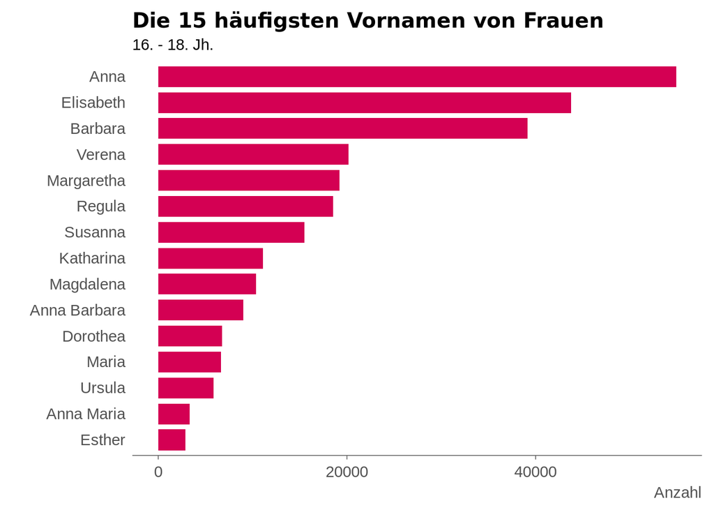

Figure 1: Die 15 beliebtesten Vornamen für Frauen im 16. - 18. Jh.

```r
TopFrau <- Frau_Vornamen |>
  group_by(Vorname_Frau) |>
  summarise(Anzahl = sum(n)) |>
  arrange(desc(Anzahl)) |>
  top_n(15, Anzahl) |>
  mutate(Prozent = Anzahl/sum(Anzahl)*100)

ggplot(data = TopFrau,
       mapping = aes(x = Anzahl,
                     y = reorder(Vorname_Frau, Anzahl)))+

  geom_col(fill = zhpal$zhwebdataviz[9], width = 0.8)+
    theme_stat()+
    theme(panel.grid.major.y = element_blank())+
  labs(title = "Die 15 häufigsten Vornamen von Frauen",
       subtitle = "16. - 18. Jh.",
       y = "")
```

Die fünfzehn beliebtesten Vornamen für Männer werden in Figure 2 dargestellt.

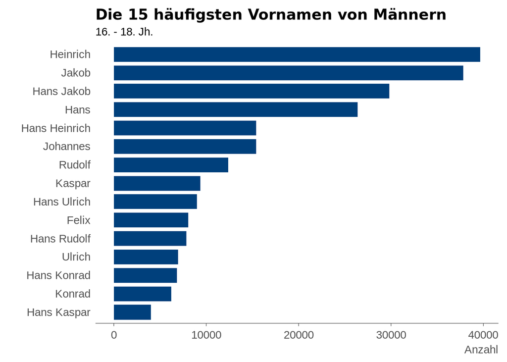

Figure 2: Die 15 beliebtesten Vornamen für Männer im 16. - 18. Jh.

```r
TopMann <- Mann_Vornamen |>
  group_by(Vorname_Mann) |>
  summarise(Anzahl = sum(n)) |>
  arrange(desc(Anzahl)) |>
  top_n(15, Anzahl) |>
  mutate(Prozent = Anzahl/sum(Anzahl)*100)

ggplot(data = TopMann,
       mapping = aes(x = Anzahl,
                     y = reorder(Vorname_Mann, Anzahl)))+

  geom_col(fill = zhpal$zhwebdataviz[2], width = 0.8)+
    theme_stat()+
    theme(panel.grid.major.y = element_blank())+
  labs(title = "Die 15 häufigsten Vornamen von Männern",
       subtitle = "16. - 18. Jh.",
       y = "")
```

### Einmalige Vornamen von Frauen

Alle Frauennamen, die nur ein einziges Mal vorkommen und keine Doppelnamen sind, werden in Table 1 anzeigt.

```r
Einmalige_Vornamen_Frau <- Frau_Vornamen |>
  filter(!grepl("\\s", Vorname_Frau)) |>
  filter(!grepl("[[:punct:]\\s]", Vorname_Frau)) |>
  group_by(Vorname_Frau) |>
  summarise(Anzahl = sum(n)) |>
  filter(Anzahl == 1) |>
  select(Vorname_Frau)

knitr::kable(Einmalige_Vornamen_Frau)
```

Table 1: Vornamen von Frauen, die nur ein einziges Mal vorkommen. Doppelnamen sind ausgenommen.

| Vorname_Frau |
| --- |
| Agga |
| Alexandra |
| Alice |
| Allida |
| Antoinette |
| Aprilla |
| Aqnna |
| Arianthia |
| Barbar |
| Bernhardina |
| Bollozina |
| Brigiol |
| Brigitte |
| Britta |
| Burga |
| Camilla |
| Candia |
| Catherine |
| Catton |
| Claranna |
| Clementia |
| Columbina |
| Cordelia |
| Cornelia |
| Demanda |
| Diamant |
| Dichtli |
| Dominika |
| Dominique |
| Dorotjea |

[output cut: 71 more lines]

### Beliebtheit der Wochentage für Eheschliessungen

An welchen Wochentagen jeweils pro Monat am meisten Ehen geschlossen worden sind, wird in Figure 3 gezeigt.

```r
Ehedaten_Datum <- Ehedaten |>
  mutate(Jahr = year(Datum),
         Monat = month(Datum, label = TRUE, abbr = FALSE),
         Wochentag = wday(Datum, label = TRUE, abbr = FALSE)) |>
  group_by(Monat, Wochentag) |>
  summarize(Anzahl = n())
```

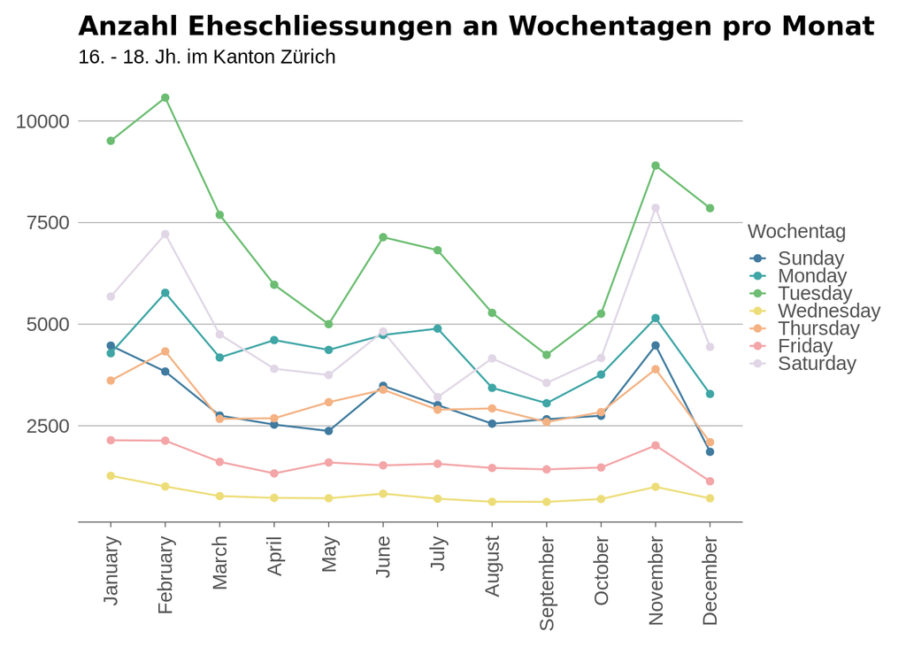

Figure 3: Anzahl der Eheschliessungen pro Monat und Wochentag im 16. - 18. Jh.

```r
   ggplot(data = Ehedaten_Datum,
         mapping = aes(x = Monat,
                       y = Anzahl,
                       group = Wochentag,
                       color = Wochentag))+

  geom_line()+
  geom_point()+
     theme_stat()+
     theme(axis.text.x = element_text(angle = 90, vjust = 0.5, hjust=1),
           legend.position = "right")+
  labs(title = "Anzahl Eheschliessungen an Wochentagen pro Monat",
       subtitle = "16. - 18. Jh. im Kanton Zürich",
       x = NULL,
       y = NULL)+
     scale_color_manual(values = zhpal$zhdiagonal)
```

# Schlussfolgerungen